# Project: Communicate Data Findings (Prosper Loan Data)

## by Shivam Chauhan

## Investigation Overview

> In this project, I have analyzed the data set contains 113,937 loans with 81 variables on loan given ny Prosper. The main objective was to explore the data using vizualization through univariate, bivariate and multivariate exploration. We will try to find which type loan are taken most and when. We will analyze which income group takes on average how much amount of loan. Finally, we will also see some trend over the years and check relation between Borrower's APR and Loan Amount.

## Dataset Overview

> The data set contains 113,937 loans with 81 variables on each loan.

### Some important features:

> - LoanStatus : Current status of the loan like chargedoff, completed, defauted etc…
> - EstimatedEffectiveYield : Yield of lenders from borrowers minus the processing fee and late fines
> - BorrowerAPR : The Borrower’s Annual Percentage Rate (APR) for the loan.
> - BorrowerRate : The Borrower’s interest rate for this loan.
> - LoanOriginalAmount : Original amount of the loan
> - LoanOriginationQuarter : Quarter of the month when loan was originated
> - Term : Length of loan expressed in months

## Which loan term are given most and when most of the loan are given?

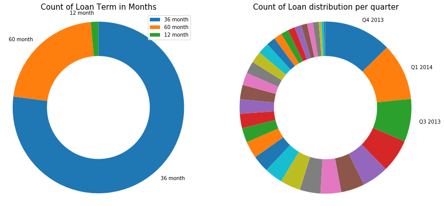

```python
#same plot with some difference
plt.figure(figsize = [14.70, 8.27])

# left plot:
plt.subplot(1, 2, 1)
sorted_counts = dfclean.Term.value_counts()
plt.pie(sorted_counts, labels = ['36 month','60 month','12 month'], startangle = 90,
        counterclock = False, wedgeprops = {'width' : 0.4});
plt.axis('square');
plt.legend();
plt.title('Count of Loan Term in Months',size =15);


# right plot:
plt.subplot(1, 2, 2)
name = [""] * len(dfclean.LoanOriginationQuarter.value_counts())
#name[:] = np.nan
c = dfclean.LoanOriginationQuarter.value_counts().index[0]
d = dfclean.LoanOriginationQuarter.value_counts().index[1]
e = dfclean.LoanOriginationQuarter.value_counts().index[2]
name[0:3] = c,d,e
sorted_counts = dfclean.LoanOriginationQuarter.value_counts()
plt.pie(sorted_counts, labels = name, startangle = 90,
        counterclock = False, wedgeprops = {'width' : 0.4});
plt.axis('square');
plt.title("Count of Loan distribution per quarter", size=15);
```

## Which income group takes most loans and how much?

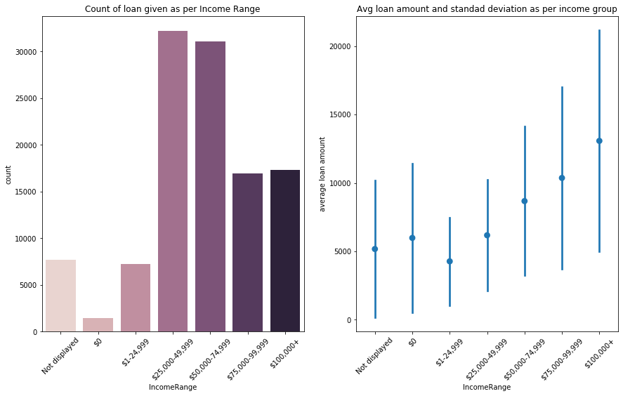

```python
plt.figure(figsize = [14.70, 8.27])

# left plot:
plt.subplot(1, 2, 1)
#bar chart for Income range
base_color = sns.cubehelix_palette(dfclean.IncomeRange.nunique(),reverse=False) #(sns.cubehelix_palette(7))
sns.countplot(x = dfclean.IncomeRange,order=ordinal_var_dict['IncomeRange'],palette=base_color);
plt.title("Count of loan given as per Income Range",size = 12);
plt.xticks(rotation=45);


# right plot:
plt.subplot(1, 2, 2)

sns.pointplot(data = dfclean, x = dfclean.IncomeRange, y = dfclean.LoanOriginalAmount , ci = 'sd',linestyles="");
plt.xticks(rotation=45);
plt.ylabel("average loan amount");
plt.title("Avg loan amount and standad deviation as per income group");
```